# Estudios de Informática, Multimedia y Telecomunicaciones

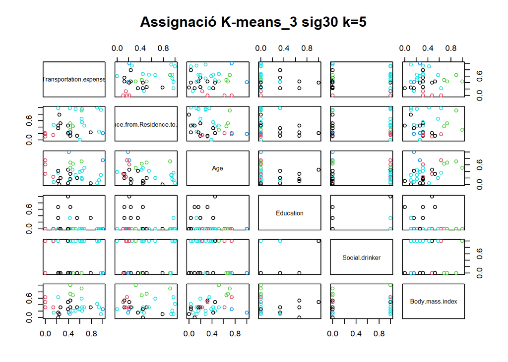

```r
plot(x, col = kmeans_3$cluster, main="Assignació K-means_3 sig30 k=5")
```

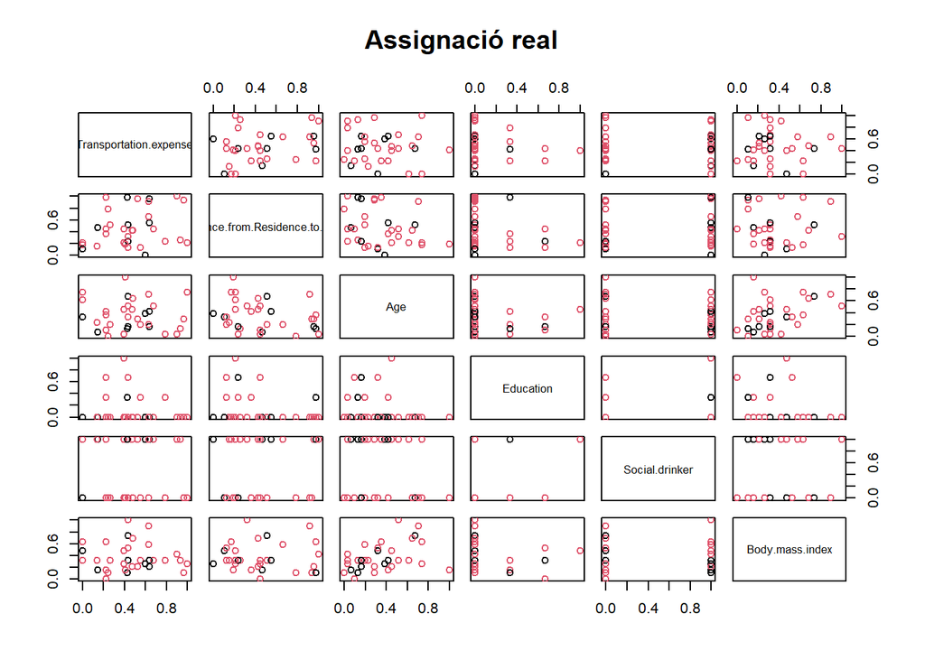

```r
plot(x, col = as.factor(AbsentismeFinal$Absenteeism.time.in.hours), main="Assignació real")
```

Com a l’exercici anterior, s’hi veu que el nou model té encara algunes dades per assignar, però que així i tot s’han pogut agrupar. De l’anàlisi visual del segon model de k-means s’extrau:

**El cost del transport:** En aquest s’hi veu que els treballadors que més gasten s’han agrupat decentment amb el color blau clar. En roig s’han mantés els que menys. Destaca que el grup blau s’ha fet molt heterogeni en aquest model.

**Distancia al lloc de treball:** Comparant-ho amb la columna del cost de transport, s’hi veu que s’han assignat als que més gasten i més lluny estan, principalment el color blau.

**Edat:** Mirant l’edat veiem que els joves són els que més lluny solen estar del lloc de treball i més gasten. Açò contradiu al model anterior.

**Educació:** La columna d’educació ara es llig a l’inrevés, sols es pot analitzar correctament per als que no tenen estudis. S’hi veu molta gent jove sense estudis i també que són els que més solen gastar-se anant al treball / més lluny estan.

**Bebedor social:** Les dades en aquest model poden llegir-se millor que en l’anterior, ja que ara tenim més resultats dels treballadors que beuen. Serien principalment joves que viuen relativament lluny del lloc de treball. Aquestes dades també contrasten amb el model anterior.

### 6.2.3 Es comenten les conclusions.

Ambdós models xoquen prou en algunes assignacions, a més ambdós no tenen un bon ajust. Ja que cap d’ells aplega al 70%. Les conclusions extretes a cada columna poden ser útils per agrupar els tipus de treballadors, però a causa del gran contrasts d’ambdós models, sembla que no és profitós.

Com anava comentant, sembla que l’estudi per k-means no és el més apropiat per aquest dataset, perquè hi ha molt poca agrupació de les dades i estan molt mesclades entre si.

Tot i que crec que els models no s’ajusten molt bé a les nostres necessitats, la informació extreta en aquests anàlisis pot ser útil si es contrasta amb altres mesures de selecció de personal. No recomane, però, que s’utilitzen sols aquestes dades per haver de fer cerques concretes.

Al capdavall, reitere que aquest algorisme no és el millor per el nostre projecte.

```r
# Neteja de dades:
remove(kmeans_1)
remove(kmeans_2)
remove(kmeans_3)
remove(kmeans_4)
remove(Uns_scale)
remove(x)
```

## 6.3 Exercici 3

### 6.3.1 S’apliquen els algorismes DBSCAN i OPTICS de forma correcta.

Ja que als exercicis anteriors s’ha vist que els millors resultats per als algorismes basats en distància era el dataset amb les columnes de significància 30, em quedaré amb aquest per tal de provar els algorismes DBSCAN i OPTICS.

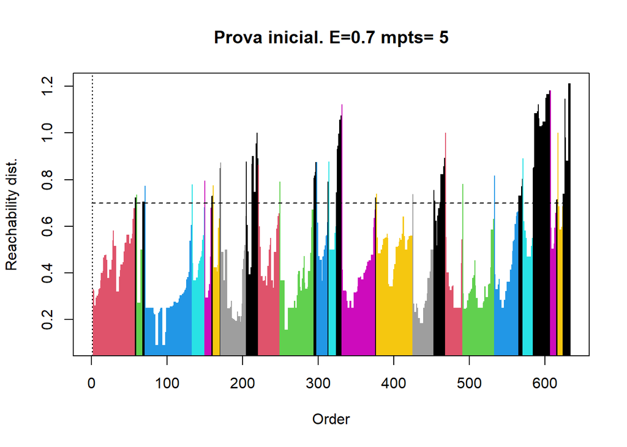

```r
# Corregist el dataset a les columnes interessades
DS_unsupervised <- Abs_Norm[sig30]

# Escalem les dades
Uns_scale <- scale(DS_unsupervised)

# DBSCAN prova inicial. Utilitzaré directament optics per poder apreciar millor les agrupacions:
opt <- optics(Abs_Norm, minPts = 5)
exdbs1 <- extractDBSCAN(opt, eps_cl = 0.7)
plot(exdbs1, main="Prova inicial. E=0.7 mpts= 5")
```

Veiem que aquesta primera agrupació hi han unes quantes dades pendents d’agrupar, i a més hi ha molts més clusters dels que necessitem. Ja que suposem que n’hauriem d’aconseguir 5 més o menys (en base als exercicis anteriors).

Primer vaig a perfilar els eps i mpts més eficients i després mostraré el resultat de l’anàlisi amb les columnes del sig30. Així es podran comparar els resultats amb els exercicis anteriors.

### 6.3.2 Es proven, descriuen i interpreten els resultats amb diferents valors d’eps.

Continue amb diverses proves:

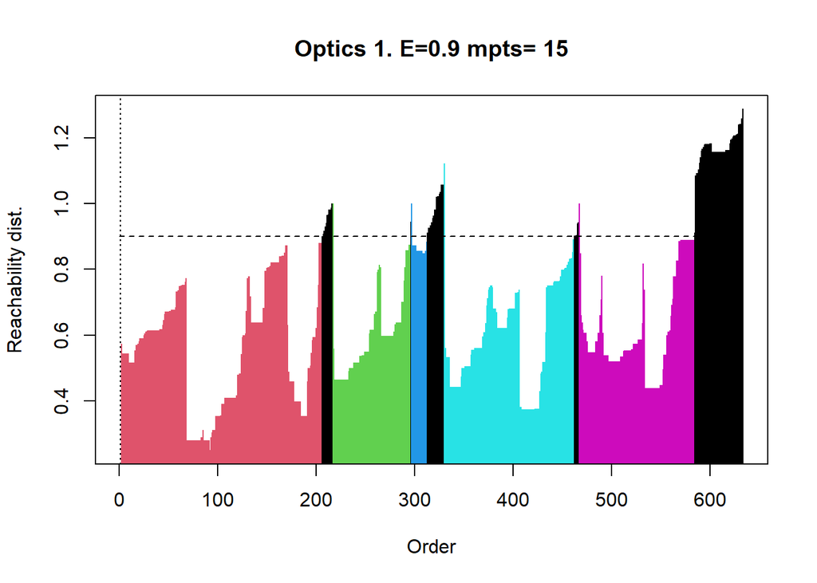

```r
opt <- optics(Abs_Norm, minPts = 15)
exdbs2 <- extractDBSCAN(opt, eps_cl = 0.9)
plot(exdbs2, main="Optics 1. E=0.9 mpts= 15")
```

En aquesta segona prova s’observen 5 agrupacions, com esperem, però amb unes quantes dades que no s’han pogut agrupar. Continue:

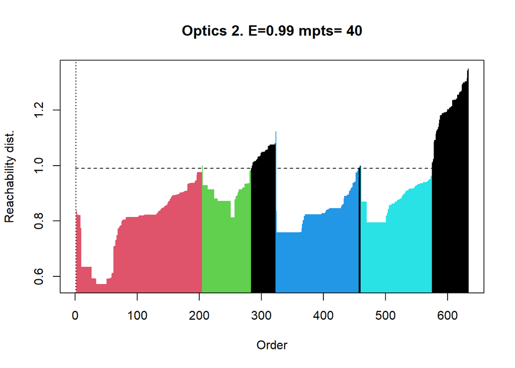

```r
opt <- optics(Abs_Norm, minPts = 40)
exdbs3 <- extractDBSCAN(opt, eps_cl = 0.99)
plot(exdbs3, main="Optics 2. E=0.99 mpts= 40")
```

En auqest he volgut comprovar un extrem dels mpts. Sembla que augmentar-los molt és cotraproduent, perquè no podem aconseguir el nombre de clsuters requerit. Tenim 4 i així i tot moltes dades per agrupar. Continue:

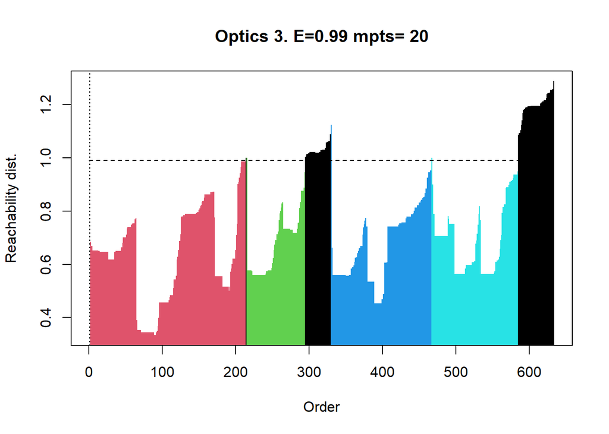

```r
opt <- optics(Abs_Norm, minPts = 20)
exdbs4 <- extractDBSCAN(opt, eps_cl = 0.99)
plot(exdbs4, main="Optics 3. E=0.99 mpts= 20")
```

En aquest tercer anàlisi d’optics hem aconseguit 4 clusters, amb les dades no seleccionades reduïdes al màxim. Ironicament s’assembla molt al optics 2. Continue:

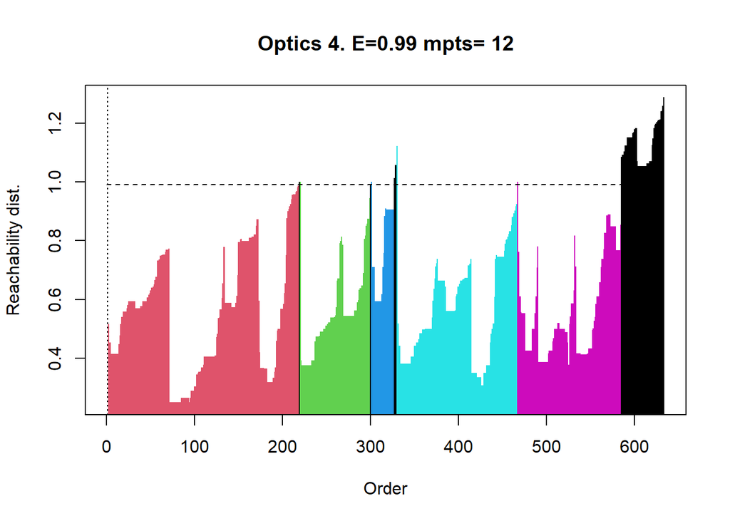

```r
opt <- optics(Abs_Norm, minPts = 12)
exdbs5 <- extractDBSCAN(opt, eps_cl = 0.99)
plot(exdbs5, main="Optics 4. E=0.99 mpts= 12")
```

En aquesta última, s’ha intentat reduïr al màxim les dades que no es poden agrupar, mentre es mantenen les 5 agrupacions. Trobe que tal vegada és el millor resultat que es pot assolir.

S’hi veu clarament que el optics_4 té el millor ajust que hem aconseguit, ja que és el que menys dades deixa per agrupar, amb grups semblants al que podiem esperar als exercicis anteriors.

Considere, per tant, que aquest és el més interessant d’analitzar i comparar amb la resta. Per tant mostre les seues columnes com als exercisis anteriors per poder-los comparar:

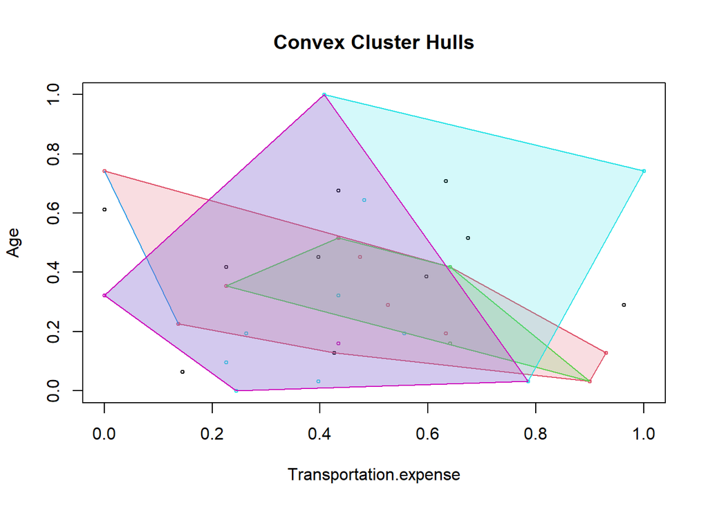

```r
hullplot(DS_unsupervised[c(1,3)],exdbs5)
```

### 6.3.3 Es comparen els resultats obtinguts dels models anteriors i DBSCAN.

Amb el hullplot anterior ja s’hi veu el problema que s’havia detectat abans. Les dades són molt disperses i no poden agrupar-se correctament amb algorismes basats en distància.

Si procure reduïr el nombre de clusters generat en l’anàlisi optics i bdscan resulta el mateix problema:

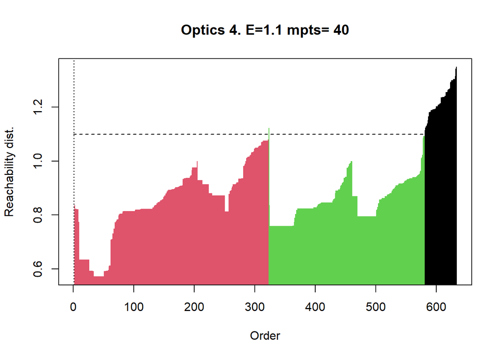

```r
opt <- optics(Abs_Norm, minPts = 40)
exdbs6 <- extractDBSCAN(opt, eps_cl = 1.1)
plot(exdbs6, main="Optics 4. E=1.1 mpts= 40")
```

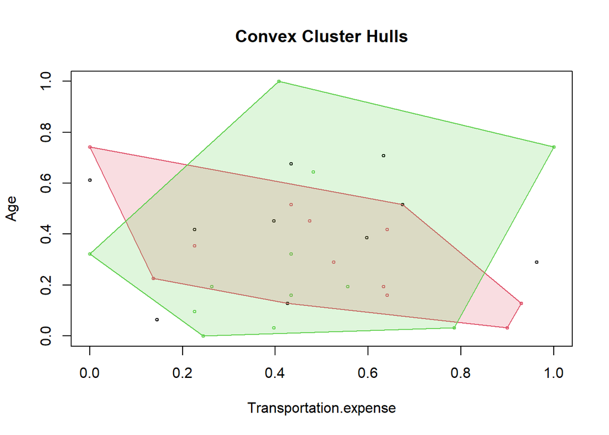

```r
hullplot(DS_unsupervised[c(1,3)], exdbs6)
```

Els clusters que s’aconsegueixen es sobreposen, i per tant no generen bons resultats. En el únic punt on es genera una bona agrupació, també perquè no hi ha alternativa per distància, és en els bebedors socials (ja que són 1 o 0):

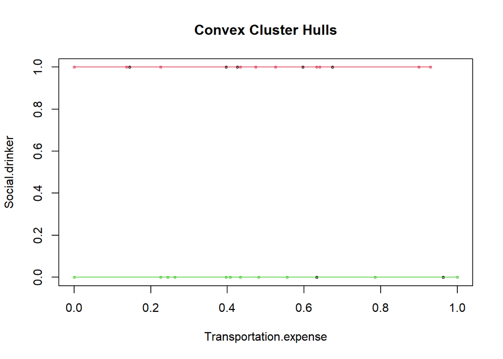

```r
hullplot(DS_unsupervised[c(1,5)], exdbs6)
```

Per tant es pot concloure que les agrupacions aconseguides a partir de k-means poden resultar més útils que les del BDSCAN/Optics, ja que les dades, com comentava, no estan ben agruapades en grups.

Tot i ser imprecises, les dades del k-means poden servir per extraure informació de contrast.

### 6.3.4 Es comenten les conclusions.

En general, i com ja s’ha anat comentant al llarg dels exercicis, sembla que aquest dataset no és molt bo per fer-li agrupacions amb algorismes basats en distància.

Com comentava, l’algorisme k-means en aquest cas és més útil que el de BDSCAN per als resultats que volem optenir. Més que res perquè la qualitat de l’agrupació del BDSCAN és pèssima perquè es sobreposen els clusters.

Amb tot, s’hauria de comunicar al departament de recursos humans els resultats del k-means com a informació de contrast de la resta d’anàlisis. No tant com a mesura de selecció o cerca de personal. Sembla que amb les dades que tenim, no es poden agrupar els treballadors correctament per tipus.

```r
# Neteja de variables:
remove(exdbs1,exdbs2,exdbs3,exdbs4,exdbs5,exdbs6,opt,Uns_scale,DS_unsupervised)
```

## 6.4 Exercici 4

Per fer l’arbre provaré d’elaborar-lo a partir dels tres datasets de significància treballats anteriorment. És a dir, provaré un arbre general amb les columnes de significació majors a 0.15 i després provaré variants de l’arbre amb les altres dades fent de poda.

La idea d’aquest algorisme és classificar els treballadors segons si al nostre client li interessaria contractar-lo, o no. Recorde que el criteri amb el que s’havia discretitzat aquesta inforamció era que amb menys o 2 hores d’absència al treball es considerava una falta normal. Més de 2 hores s’havia considerat que no es recomanava contractar aquest tipus de treballador.

Així doncs, elabore les dades necessàries per crear els arbres i n’extrauré les regles principals.

### 6.4.1 Es generen regles i es comenten i interpreten les més significatives.

```r
# Guarde ara les dades discretitzades a una copia. Utilitze per a l'arbre les dades numeriques sense normalitzar per poder llegir les regles i que tinguen més sentit que amb els valors normalitzats. Pel que he pogut cercar, aquesta decisió no afecta al resultat de l'arbre: https://datascience.stackexchange.com/questions/5277/do-you-have-to-normalize-data-when-building-decision-trees-using-r

# Genere la copia:
data <- AbsentismeNormal

# Randomitze les dades:
set.seed(1)
datard <- data[sample(nrow(data)),]

# Columnes de sig. 0.3:
D30 <- datard[,sig30]

# Columnes de sig. 0.2:
D20 <- datard[,sig20]

# Columnes de sig. 0.15:
D15 <- datard[,sig15]
```

Ara que ja estan les dades randomitzades i seleccionades vaig a dividir les dades en mostres de prova i entrenament. 2/3 per la d’entrenament i 1/3 per la de prova.

```r
# Definisc la variable target:
set.seed(422)
y <- datard[,17]

# Prepare la resta:
Ax <- D30
Bx <- D20
Cx <- D15

# Dividisc les dades:
split <- 3
max_split<-floor(nrow(Ax)/split)
tr_limit <- nrow(Ax)-max_split
test_limit <- max_split*2+1

# Valors target:
try <- y[1:tr_limit]
testy <- y[test_limit:nrow(Ax)]

# Valors Ax:
trAx <- Ax[1:tr_limit,]
testAx <- Ax[test_limit:nrow(Ax),]

# Valors Bx:
trBx <- Bx[1:tr_limit,]
testBx <- Bx[test_limit:nrow(Ax),]

# Valors Cx:
trCx <- Cx[1:tr_limit,]
testCx <- Cx[test_limit:nrow(Ax),]
```

Ara que ja tinc les dades seleccionades per fer l’entrenament de l’arbre i el seu test, comprove rapidament que les dades s’han inserit correctament i que les dimensions són les esperades:

```r
# Dades d'entrenament:
str(try)
```

```
##  num [1:422] 2 2 1 2 2 2 1 2 1 2 ...
```

```r
dim(trAx)
```

```
## [1] 422   6
```

```r
dim(trBx)
```

```
## [1] 422   8
```

```r
dim(trCx)
```

```
## [1] 422   9
```

```r
# Dades de test:
str(testy)
```

```
##  num [1:211] 1 1 1 2 2 2 2 2 1 2 ...
```

```r
dim(testAx)
```

```
## [1] 211   6
```

```r
dim(testBx)
```

```
## [1] 211   8
```

```r
dim(testCx)
```

```
## [1] 211   9
```

Totes les variables s’han emplenat amb les dades i columnes correctes. Per tant ara generaré una primera prova dels arbres de decisió:

```r
tryf = as.factor(try)

modelAx <- C50::C5.0(trAx, tryf, rules=TRUE)
modelBx <- C50::C5.0(trBx,tryf,rules=TRUE)
modelCx <- C50::C5.0(trCx,tryf,rules=TRUE)
```

Aquests arbres són una primera vista a la solució d’aquest model. S’han fet els tres sense boost per veure quina és la taxa d’error de cadascun i així esbrinar quin és el més interessant de mantenir.

### 6.4.2 Comparació de les taxes d’error i matrius de confusió

En aquest apartat vaig a comparar les taxes d’error de cadascun dels arbres generats per veure quin és el més interessant de mantenir. Després generaré les seues matrius de confusió per comprovar també com s’ajusten al dataset.

A partir d’aquest anàlisi, al següent apartat seleccionaré un arbre definitiu per analitzar les seues regles i mostraré la seua representació gràfica.

Així doncs, mostre els arbres:

```r
summary(modelAx)
```

```
##
## Call:
## C5.0.default(x = trAx, y = tryf, rules = TRUE)
##
##
## C5.0 [Release 2.07 GPL Edition]      Wed Jun 15 20:08:05 2022
## -------------------------------
##
## Class specified by attribute `outcome'
##
## Read 422 cases (7 attributes) from undefined.data
##
## Rules:
##
## Rule 1: (131/63, lift 1.4)
##  Transportation.expense <= 228
##  Social.drinker <= 0
##  ->  class 1  [0.519]
##
## Rule 2: (176/40, lift 1.2)
##  Transportation.expense > 228
##  ->  class 2  [0.770]
##
## Rule 3: (236/77, lift 1.1)
##  Social.drinker > 0
##  ->  class 2  [0.672]
##
## Default class: 2
##
##
## Evaluation on training data (422 cases):
##
##          Rules
##    ----------------
##      No      Errors
##
##       3  155(36.7%)   <<
##
##
##     (a)   (b)    <-classified as
##    ----  ----
##      68    92    (a): class 1
##      63   199    (b): class 2
##
##
##  Attribute usage:
##
##   86.97% Social.drinker
##   72.75% Transportation.expense
##
##
## Time: 0.0 secs
```

```r
summary(modelBx)
```

```
##
## Call:
## C5.0.default(x = trBx, y = tryf, rules = TRUE)
##
##
## C5.0 [Release 2.07 GPL Edition]      Wed Jun 15 20:08:05 2022
## -------------------------------
##
## Class specified by attribute `outcome'
##
## Read 422 cases (9 attributes) from undefined.data
##
## Rules:
##
## Rule 1: (52/16, lift 1.8)
##  Transportation.expense <= 228
##  Work.load.Average.day > 306.345
##  ->  class 1  [0.685]
##
## Rule 2: (176/40, lift 1.2)
##  Transportation.expense > 228
##  ->  class 2  [0.770]
##
## Rule 3: (349/121, lift 1.1)
##  Work.load.Average.day <= 306.345
##  ->  class 2  [0.652]
##
## Default class: 2
##
##
## Evaluation on training data (422 cases):
##
##          Rules
##    ----------------
##      No      Errors
##
##       3  140(33.2%)   <<
##
##
##     (a)   (b)    <-classified as
##    ----  ----
##      36   124    (a): class 1
##      16   246    (b): class 2
##
##
##  Attribute usage:
##
##   95.02% Work.load.Average.day
##   54.03% Transportation.expense
##
##
## Time: 0.0 secs
```

```r
summary(modelCx)
```

```
##
## Call:
## C5.0.default(x = trCx, y = tryf, rules = TRUE)
##
##
## C5.0 [Release 2.07 GPL Edition]      Wed Jun 15 20:08:05 2022
## -------------------------------
##
## Class specified by attribute `outcome'
##
## Read 422 cases (10 attributes) from undefined.data
##
## Rules:
##
## Rule 1: (66/21, lift 1.8)
##  Month.of.absence <= 2
##  Transportation.expense <= 228
##  ->  class 1  [0.676]
##
## Rule 2: (28/9, lift 1.8)
##  Month.of.absence > 3
##  Transportation.expense <= 228
##  Distance.from.Residence.to.Work <= 14
##  Social.drinker > 0
##  ->  class 1  [0.667]
##
## Rule 3: (35/13, lift 1.6)
##  Transportation.expense <= 228
##  Work.load.Average.day <= 294.217
##  Social.drinker <= 0
##  Body.mass.index <= 23
##  ->  class 1  [0.622]
##
## Rule 4: (31/12, lift 1.6)
##  Month.of.absence > 2
##  Transportation.expense <= 228
##  Distance.from.Residence.to.Work <= 14
##  Social.drinker > 0
##  ->  class 1  [0.606]
##
```

[output cut: 28 more lines]

```
##      82    78    (a): class 1
##      43   219    (b): class 2
##
##
##  Attribute usage:
##
##   95.97% Month.of.absence
##   72.99% Transportation.expense
##   19.19% Social.drinker
##   11.85% Body.mass.index
##    8.29% Work.load.Average.day
##    7.35% Distance.from.Residence.to.Work
##
##
## Time: 0.0 secs
```

S’hi pot observar que els tres arbres tenen prou bons marges d’error.

- El primer, **Ax**, amb les columnes de significància majors al 0.30, ha aconseguit un error del 36%.
- El segon, **Bx**, amb les columnes de significància majors al 0.20, ha aconseguit un error del 33.2%. Una millora respecte a l’anterior.
- Finalment el tercer, **Cx**, amb les columnes de significància majors al 0.15, ha aconseguit un error del 28.7%. També millora respecte de l’anterior.

Aquestes dades no són gens roïns per a arbres generats sense boost. Comprovaré ara el seu comportament amb les dades de test, i generaré la seua matriu de confusió. Adicionalment imprimiré la seua precisió:

```r
# Percentatge d'encerts:
predicted_model <- predict( modelAx, testAx, type="class" )
print(sprintf("La precisió de l'arbre és del: %.4f %%",100*sum(predicted_model == testy) / length(predicted_model)))
```

```
## [1] "La precisió de l'arbre és del: 59.2417 %"
```

```r
# matriu de confusió:
# Mostre la matriu de confusió
mat_conf<-table(testy,Predicted=predicted_model)
mat_conf
```

```
##      Predicted
## testy  1  2
##     1 36 49
##     2 37 89
```

Per al primer arbre, s’hi veu que té una precisió del 59.2% i la matriu de confusió tendeix a afavorir els falsos positius (49). S’ha de destacar que aquest arbre genera més falsos negatius que positius reals.

Per tant ens indica que hi ha molta gent que podria treballar productivament i no es contracta, mentre que hi ha molta gent que es contracta que no va a ser productiu.

```r
# Percentatge d'encerts:
predicted_model <- predict( modelBx, testBx, type="class" )
print(sprintf("La precisió de l'arbre és del: %.4f %%",100*sum(predicted_model == testy) / length(predicted_model)))
```

```
## [1] "La precisió de l'arbre és del: 60.6635 %"
```

```r
# matriu de confusió:
# Mostre la matriu de confusió
mat_conf<-table(testy,Predicted=predicted_model)
mat_conf
```

```
##      Predicted
## testy   1   2
##     1  10  75
##     2   8 118
```

En el segon arbre veiem que la precisió és del 60.6%, quasi igual a l’arbre anterior. La diferència es troba a la matriu de confusió, ja que aquest arbre dóna un pijor resultat que l’anterior.

En aquest el problema dels falsos positius augmenta i és molt més superior que els positius reals (FP = 75 vs PR = 10). Per tant tenim un resultat en que l’arbre classifica sobretot als treballadors que no serien productius com treballadors productius.

```r
predicted_model <- predict( modelCx, testCx, type="class" )
print(sprintf("La precisió de l'arbre és del: %.4f %%",100*sum(predicted_model == testy) / length(predicted_model)))
```

```
## [1] "La precisió de l'arbre és del: 60.1896 %"
```

```r
mat_conf<-table(testy,Predicted=predicted_model)
mat_conf
```

```
##      Predicted
## testy   1   2
##     1  24  61
##     2  23 103
```

Finalment per al tercer arbre veiem que la precisió segueix igual, amb un 60.2%, i la matriu de confusió repeteix els problemes anteriors.

Veiem com els falsos positius segueixen essent un problema, i segueixen sent més que els positius reals (FP = 61 vs PR = 24). Mantenim per tant els problemes anteriors

### 6.4.3 Comparació dels millors arbres per poda i boost:

Havent observat els resultats que ens han donat els arbres, queda clar que no hi ha molta millora d’uns a altres. Tot i que l’error baixa d’un arbre al següent, el problema principal, el dels falsos positius, persisteix.

He provat també a fer l’arbre a partir de totes les columnes del dataset i tot i que millorava la precisió i l’error, el problema dels falsos positius persistia.

És per això que he volgut fer una comparació final entre els arbres que més interés m’han despertat: el Ax per la seua baixa taxa de FP (en comparació), i el Cx pel seu baix error.

Imprimiré amdós ara amb boost:

```r
# Genere els models amb boost:
modelAxt <- C50::C5.0(trAx,tryf, trials = 10)
modelCxt <- C50::C5.0(trCx,tryf, trials = 10)
summary(modelAxt)
```

```
##
## Call:
## C5.0.default(x = trAx, y = tryf, trials = 10)
##
##
## C5.0 [Release 2.07 GPL Edition]      Wed Jun 15 20:08:05 2022
## -------------------------------
##
## Class specified by attribute `outcome'
##
## Read 422 cases (7 attributes) from undefined.data
##
## -----  Trial 0:  -----
##
## Decision tree:
##
## Transportation.expense > 228: 2 (176/40)
## Transportation.expense <= 228:
## :...Social.drinker <= 0: 1 (131/63)
##     Social.drinker > 0: 2 (115/52)
##
## -----  Trial 1:  -----
##
## Decision tree:
##  2 (422/169.5)
##
## *** boosting reduced to 1 trial since last classifier is very inaccurate
##
## *** boosting abandoned (too few classifiers)
##
##
## Evaluation on training data (422 cases):
##
##      Decision Tree
##    ----------------
##    Size      Errors
##
##       3  155(36.7%)   <<
##
##
##     (a)   (b)    <-classified as
##    ----  ----
##      68    92    (a): class 1
##      63   199    (b): class 2
##
##
##  Attribute usage:
##
##  100.00% Transportation.expense
##   58.29% Social.drinker
##
##
## Time: 0.0 secs
```

```r
summary(modelCxt)
```

```
##
## Call:
## C5.0.default(x = trCx, y = tryf, trials = 10)
##
##
## C5.0 [Release 2.07 GPL Edition]      Wed Jun 15 20:08:05 2022
## -------------------------------
##
## Class specified by attribute `outcome'
##
## Read 422 cases (10 attributes) from undefined.data
##
## -----  Trial 0:  -----
##
## Decision tree:
##
## Transportation.expense > 228: 2 (176/40)
## Transportation.expense <= 228:
## :...Month.of.absence <= 2:
##     :...Work.load.Average.day <= 253.957: 2 (7/2)
##     :   Work.load.Average.day > 253.957: 1 (59/16)
##     Month.of.absence > 2:
##     :...Social.drinker <= 0:
##         :...Body.mass.index > 23: 2 (56/18)
##         :   Body.mass.index <= 23:
##         :   :...Work.load.Average.day <= 294.217: 1 (31/13)
##         :       Work.load.Average.day > 294.217: 2 (4)
##         Social.drinker > 0:
##         :...Distance.from.Residence.to.Work > 14: 2 (58/20)
##             Distance.from.Residence.to.Work <= 14:
##             :...Month.of.absence <= 3: 2 (3)
##                 Month.of.absence > 3: 1 (28/9)
##
## -----  Trial 1:  -----
##
## Decision tree:
##
## Social.drinker > 0: 2 (234.4/89.8)
## Social.drinker <= 0:
## :...Month.of.absence <= 3: 1 (64.1/24.4)
```

[output cut: 60 more lines]

```
##
##  Attribute usage:
##
##  100.00% Transportation.expense
##  100.00% Son
##  100.00% Social.drinker
##   73.70% Education
##   71.56% Month.of.absence
##   48.10% Age
##   23.93% Work.load.Average.day
##   21.56% Body.mass.index
##   21.09% Distance.from.Residence.to.Work
##
##
## Time: 0.0 secs
```

Per una banda tenim que el primer arbre, Ax, manté la taxa d’error del 36.7%; mentre que el segon, Cx, té la mateixa taxa d’error del 29% (abans era del 28.7%).

Al primer el boost no ha tingut un efecte pel nombre elevat d’errors, mentre que al segon s’han aconseguit fins a cinc intents. Cal notar que l’error en cada intent superava per molt l’error del primer arbre, amb alguns pasos amb un error major del 45%.

Al capdavall, tot i que el segon arbre té una taxa d’error menor amb i sense boost, el problema dels falsos positius considere que és suficientment greu com per no escollir aquest. Recorde que aquest classificava quasi tres vegades més el nombre de falsos positius que el de positius reals.

El primer arbre, l’Ax, tot i tenir un error en l’assignació prou elevada, la precisió era quasi igual que al arbre Cx. Així mateix, el nombre de falsos positius sols era un poc major (PR = 36, FP = 49).

Segueixen essent dades dolentes, però són molt millors que les del arbre Cx, que les assignacions correctes eren ínfimes.

### 6.4.4 Arbre definitiu i representació gràfica:

Per tot el que he explicat prèviament, considere que el millor model de classificació per al nostre client és l’Ax. Açò és, sobretot, perquè el client estava especialment preocupat en tenir treballadors productius. Per tant, augmentar injustificadament, i desproporcionalment, el nombre de falsos positius seria un gran error.

Amb tot, mostre l’arbre i la seua representació:

```r
# Mostre l'arbre:
summary(modelAx)
```

```
##
## Call:
## C5.0.default(x = trAx, y = tryf, rules = TRUE)
##
##
## C5.0 [Release 2.07 GPL Edition]      Wed Jun 15 20:08:05 2022
## -------------------------------
##
## Class specified by attribute `outcome'
##
## Read 422 cases (7 attributes) from undefined.data
##
## Rules:
##
## Rule 1: (131/63, lift 1.4)
##  Transportation.expense <= 228
##  Social.drinker <= 0
##  ->  class 1  [0.519]
##
## Rule 2: (176/40, lift 1.2)
##  Transportation.expense > 228
##  ->  class 2  [0.770]
##
## Rule 3: (236/77, lift 1.1)
##  Social.drinker > 0
##  ->  class 2  [0.672]
##
## Default class: 2
##
##
## Evaluation on training data (422 cases):
##
##          Rules
##    ----------------
##      No      Errors
##
##       3  155(36.7%)   <<
##
##
##     (a)   (b)    <-classified as
##    ----  ----
##      68    92    (a): class 1
##      63   199    (b): class 2
##
##
##  Attribute usage:
##
##   86.97% Social.drinker
##   72.75% Transportation.expense
##
##
## Time: 0.0 secs
```

```r
# Mostre la seua precisió i la matriu de confusió:
# Percentatge d'encerts:
predicted_model <- predict( modelAx, testAx, type="class" )
print(sprintf("La precisió de l'arbre és del: %.4f %%",100*sum(predicted_model == testy) / length(predicted_model)))
```

```
## [1] "La precisió de l'arbre és del: 59.2417 %"
```

```r
# matriu de confusió:
# Mostre la matriu de confusió
mat_conf<-table(testy,Predicted=predicted_model)
mat_conf
```

```
##      Predicted
## testy  1  2
##     1 36 49
##     2 37 89
```

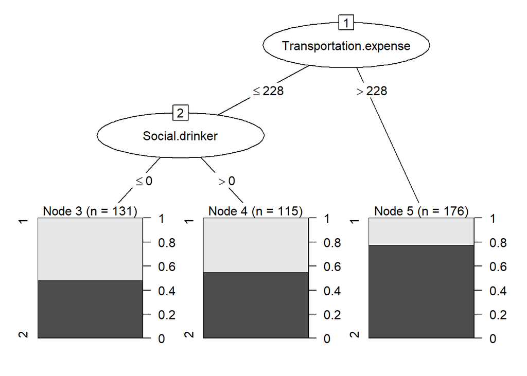

```r
# Mostre la seua representació gràfica:
plotmodel <- C50::C5.0(trAx,tryf)
plot(plotmodel)
```

**Les seues normes són:**

1. Si el treballador tindria més despeses que 228 no es contracta.
2. Si el treballador tindria unes despeses menors o iguals a 228, es mira si beu alcohol.

2.1 Si el treballador tindria unes despeses menors o iguals a 228 i beu alcohol no es contracta.

2.2 Si el treballador tindria unes despeses menors o iguals a 228 i no beu alcohol es contracta.

### 6.4.5 Es comenten les conclusions.

El arbre final que s’ha obtingut en aquest model és útil si es vol automatitzar la selecció de personal, però trobe que serviria realment sols com a suport d’una entrevista prèvia. Tot pel gran nombre d’errors i falsos positius.

Amb una precisió del 60%, té unes normes molt senzilles d’interpretar pel client. Per posar en context que significa que el seu cost de transport siga menor o no de 228 imprimiré ara els valors de la columna:

```r
#Mostre les dades úniques:
sort(unique(AbsentismeNormal$Transportation.expense))
```

```
##  [1] 118 155 157 179 184 189 225 228 233 235 246 248 260 268 279 289 291 300 330
## [20] 361 369 378 388
```

```r
# Mostre el resum de les dades:
summary(AbsentismeNormal$Transportation.expense)
```

```
##    Min. 1st Qu.  Median    Mean 3rd Qu.    Max.
##   118.0   179.0   225.0   219.8   260.0   388.0
```

S’hi veu clarament que aquest nombre fa referència (s’hi aproxima) a la mediana de les dades, un poc més elevada que la mitjana d’aquestes. Per tant simplement s’hauria de calcular, per part del client, el cost aproximat de transport fins al lloc de treball i a partir d’ahi vigilar.

Aquest arbre no s’hauria d’aplicar com a tal, perquè perfectament el client podria cercar un lloc per la seua fàbrica on hi haja molt de transport públic o la distància siga mínima (al centre urbà). Per tant els costos de transport baixarien i entrarien més treballadors.

Al capdavall, aquest model ha de servir de suport a altres formes de selecció de personal, no ha de servir com a única opció. Ja que a la gràfica s’observa que molts falsos negatius, per exemple, és perquè ténen despeses elevades (que no seria problema perquè serien productius si poden mantenir-se amb el seu sou). Indepdendentment, és útil sobretot com a contrast amb altres formats de selecció de personal.

## 6.5 Exercici 5

En aquest exercici he volgut provar l’algorisme K-NN. He vist que també serveix per a models de classificació, així que crec que serà interessant comparar els resultats amb l’exercici anterior.

Seguint els exemples de la referència que he utilitzat, prepararé les dades per poder entrenar el model i després avaluar-lo:

```r
# Referència:
# https://towardsdatascience.com/k-nearest-neighbors-algorithm-with-examples-in-r-simply-explained-knn-1f2c88da405c

# Se'ns recomana utilitzar les dades normalitzades, així que les guardaré en noves variables:# Genere la copia:
dataknn <- Abs_Norm

# Randomitze les dades:
set.seed(1)
datardk <- dataknn[sample(nrow(dataknn)),]

# Columnes de sig. 0.3, ja que són les que he escollit a l'exercici anterior al final:
KD15 <- datardk[,sig30]
```

Una vegada tinc les dades preparades, guarde les dades d’entrenament i de testeig, com a l’arbre, per provar aquest model.

Finalment imprimiré la precisió obtinguda i la seua matriu de confusió:

```r
# Definisc la variable target:
set.seed(422)
y <- datard[,17]

# Prepare la resta:
KNN <- KD15

# Valors KNN:
trKNN <- KNN[1:tr_limit,]
testKNN <- KNN[test_limit:nrow(KNN),]

# Ací es duplica, perquè procure replicar el codi d'exemple i partia del meu codi.

# Agafe les dades i les seleccione per al test:
Knn_train <- trKNN
knn_test <- testKNN

# Agafe la columna target:
target <- try
test <- testy

# Cree el Knn:
pr <- knn(Knn_train,knn_test,cl=target,k=40)

# Matriu de confusió:
tab <- table(pr,test)

certesa <- function(x){sum(diag(x)/(sum(rowSums(x)))) * 100}

# Mostre la precisió:
print(sprintf("La precisió del model K-NN és del: %.4f %%",certesa(tab)))
```

```
## [1] "La precisió del model K-NN és del: 64.9289 %"
```

```r
# Mostre la matriu de confussió:
print(tab)
```

```
##    test
## pr    1   2
##   1  25  14
##   2  60 112
```

### 6.5.1 Conclusions del nou model:

Considere que aquest model és una millora important respecte dels anteriors perquè aquest sí serviria correctament per la selecció de personal. El nostre client estava especialment preocupat per contractar sols treballadors productius, i aquest model ens assegura que la majoria dels treballadors contractats seran productius.

Sí és cert que hi hauran molts treballadors hàbils per al lloc de treball que no l’aconseguiran (FN = 60), però si el client prepara amb suficient antelació la deslocalització de la seua productivitat, aquest seria el millor model per traslladar-se, per ser més conservador i per tant segur.

## 6.6 Exercici 6

### 6.6.1 Identifica quines possibles limitacions tenen les dades que has seleccionat per obtenir conclusions amb els models (supervisat i no supervisat)

Aquest dataset, com s’ha anat veient a l’execució dels exercicis, funciona molt millor en models de classificació supervisats que no amb models no supervisats basats en distància.

Els primers algorismes, K-means i BDSCAN/Optics, han donat resultats molt inconcisos que aporten poc al coneixement que demanava el nostre client. A més, s’hi podien extraure millors conclusions a través de l’anàlisi visual que es va fer a la pràctica_1.

Amb tot, crec que aquest dataset sí serviria per acconsellar al nostre client en la seua cerca de personal productiu, però com he comentat a pràcticament tots els punts, tots els models generats haurien de contrastar-se amb altres mètodes com l’anàlisi de les dades visualment o entrevistes de treball.

### 6.6.2 S’identifiquen possibles riscos de fer servir el model (mínim 300 paraules).

Els riscos principals són els ben bé ja he anat comentant al llarg del projecte. El nostre client necessitaria compaginar aquestes ferramentes amb altres mètodes de selecció de personal.

L’anàlisi visual de les dades (pràctica_1) donava molta informació clau que podrien utilitzar els departaments de recursos humans per la selecció de les dades. Informació que en els models presentats, supervisats o no, no es tenen en compte.

Per exemple, sabíem que hi havien dies que els treballadors tenien més hores absents. Al igual que hi havien mesos amb més absències. Totes aquestes dades, clau per a la selecció del personal (que no podem saber perquè depenen de la jornada que instaure el client) no es tenen en compte.

Per altra banda, pel que fa als models no supervisats, les seues dades són difícils de llegir. És cert que aconsegueixen agrupar les dades, sobretot al mètode de k-means, però aquestes dades no aporten molta més informació de la que aportava l’anàlisi visual de les dades. Per això remarcava que aquest havia de servir per contextualitzar l’altre anàlisi, i no fer-lo servir de manera independent.

L’anàlisi DBSCAN/Optics no ha resultat ser satisfactori perquè les dades estaven poc agrupades i desordenades, generant caixes que es sobreposaven. No tinc molt a comentar sobre aquest, ja que no ha funcionat com s’esperava.

Pel que fa als models supervisats s’ha vist que poden ser útils per la selecció de personal. Els arbres de decisió tenen molts riscos d’aplicar-se, ja que el client podria estar contractant molts treballadors potencialment poc productius. Açò després repercutira amb la nostra imatge d’assessoria i empitjoraria la nostra relació amb el client. A més, la credibilitat per predir l’activitat laboral al Brasil cauria i no seria gens bo per al nostre negoci.

El millor de tots els models sembla ser el de K-NN, amb uns falsos positius reduïts a costa d’un alt nombre de falsos negatius. Els principals riscos d’aquest és que igualment es van a contractar treballadors no productius, però seran menys. A més la contractació de personal seria més lenta perquè s’hauria de descartar molts candidats que sí serien productius.

Amb tot, com he reiterat moltes vegades, s’ha de transmetre al client que aquests models són compatibles entre ells, però cap d’ells ha d’utilitzar-se en exclusiu. **De necessitar un sol model per automatitzar la selecció de personal, recomanaria el model K-NN i compaginar-lo amb l’anàlisi visual de les dades** i altres mecanismes propis del departament de recursos humans. De no ser aquest el cas, totes les ferramentes ajudarien a extraure coneixement, tenint en compte els riscos comentats prèviament.